# Homework 1 Solutions

### Exercise 3:

Make a bar plot of `manufacturer`. Flip it so that the manufacturers are on the y-axis. Order the bars by height. Which manufacturer produced the most cars? Which produced the least?

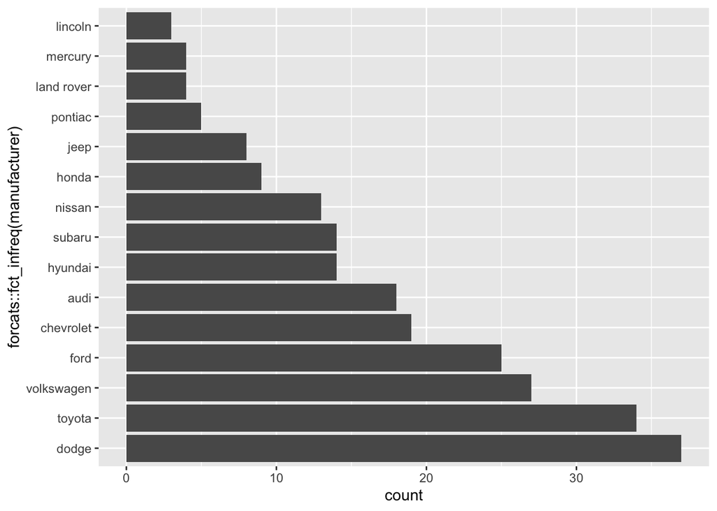

```r
mpg %>%
  ggplot(aes(x = forcats::fct_infreq(manufacturer))) +
  geom_bar() +
  coord_flip()
```

*Dodge produced the most cars, almost 40; Lincoln produced the least, below 5.*

### Exercise 4:

Make a box plot of `hwy`, grouped by `cyl`. Do you see a pattern? If so, what?

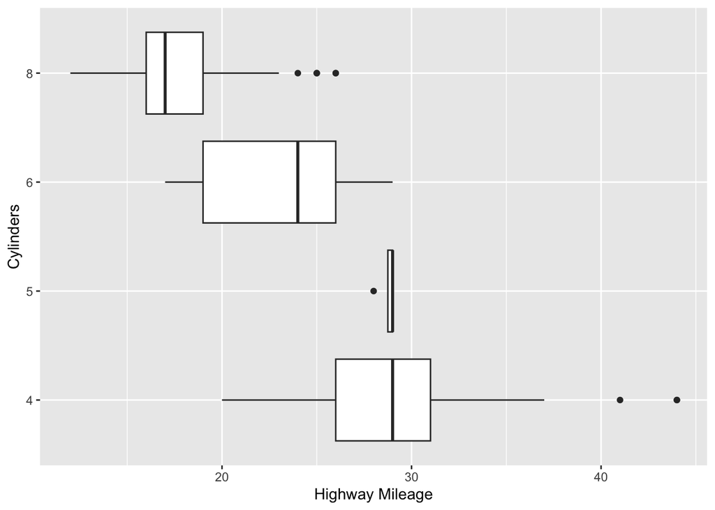

```r
mpg %>%
  ggplot(aes(x = hwy, y = factor(cyl))) +
  geom_boxplot() +
  xlab("Highway Mileage") +
  ylab("Cylinders")
```

*Yes; as the number of cylinders increases, the highway mileage tends to decrease. Cars with four cylinders have the highest mileage on average. Five-cylinder cars are close in terms of average, but there are far fewer five-cylinder cars in the data set.*